# Introduction to remixsiar

CJ Brown

2017-07-28

This package provides helpful functions for evaluating the results of isotope mixing models.  
Currently it works directly with the package (`simmr`)[]. Many of the functions are not exclusive to `simmr` classes, however a greater profeciency at R programming would be required to use this package with packages other than `simmr`.

In the future we plan to extend `remixsiar` to other mixing model packages.

## Getting started

We recommend you read the `simmr` vignette by typing `vignette('simmr')` before you start with this package. Assuming you are already familiar with `simmr` then you can start with one of our example data-sets, gulls:

```r
library(remixsiar)
data(gulls_small)
```

Next use `simmr` to build the mixing model input and run the mixing model (this may take a few moments).

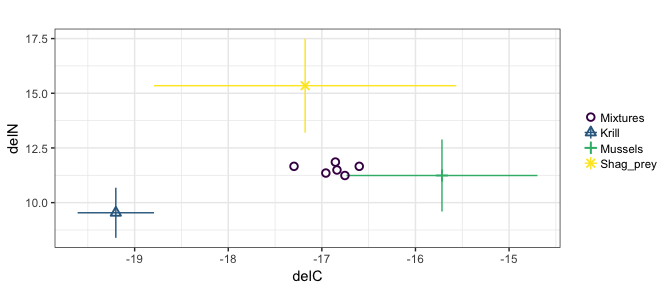

```r
gulls_small_in <- simmr_load(mixtures=gulls_small$mixes,
                       source_names=gulls_small$s_names,
                       source_means=gulls_small$source_means,
                       source_sds=gulls_small$source_sds)

plot(gulls_small_in, title = '')
```

## Prior sensitivity analysis

With small samples sizes the estimates of dietary proportions from Bayesian isotope mixing models may be strongly influenced by their priors. Most models will run with a default prior that is not directly visible to the user. `remixsiar` provides utilities for viewing the prior.

To generate the parameters for the default prior for the gulls data in `simmr` type:

```r
prior_gulls <- default_prior(gulls_small_in)
prior_gulls
```

```
## $means
## [1] 0 0 0
##
## $sd
## [1] 1 1 1
```

The gulls data-set is based on data from [Masello et al. 2013](http://journals.plos.org/plosone/article?id=10.1371/journal.pone.0067714#s5)

As you can see it is a series of three means and sds, one for each source. `simmr` and other newer mixing models use logistic-normal transformations to generate posterior samples of dietary proportions. The priors are specified in terms of normal distributions, which are then transformed to dietary proportions for the puproses of estimating isotope mixing in consumers.

A user might want to view the (latent) priors in terms of proportions. To view the priors for the krill source type:

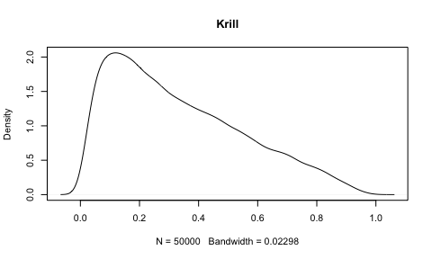

```r
gpd <- drawpriors(gulls_small_in, prior_gulls)
plot(density(gpd[,'Krill']), main = 'Krill')
```

Notice that the priors are broad, they cover values from 0 to 1, however, they are peaked at lower values. So the priors are weakly informative, not uniniformative as is commonly assumed. In fact, the mean will be 1/number of sources. Priors on proportions have to be informative because there are more ways to sum intermediate numbers to obtain 1 than extreme numbers.

We can do a visual comparison of prior and posterior distributions using `remixsiar`, but first we need to run the `simmr` model:

```r
prior_gulls <- default_prior(gulls_small_in)
mcmccontrol <- list(iter = 50000, burn = 1000, thin = 10, n.chain = 4)
```

```r
gulls_out <- simmr_mcmc(gulls_small_in, prior.control = prior_gulls, mcmc.control = mcmccontrol)
```

(for convenience the output from the above model run can be obtained by typing `data(gulls_out)`)

```r
summary(gulls_out)
```

```
## Gelman diagnostics - these values should all be close to 1.
## If not, try a longer run of simmr_mcmc.
##           Point est. Upper C.I.
## Krill              1          1
## Mussels            1          1
## Shag_prey          1          1
## sd_delC            1          1
## sd_delN            1          1
##            2.5%   25%   50%   75% 97.5%
## Krill     0.135 0.249 0.302 0.353 0.450
## Mussels   0.289 0.436 0.500 0.564 0.698
## Shag_prey 0.059 0.146 0.198 0.252 0.369
## sd_delC   0.012 0.122 0.265 0.477 1.183
## sd_delN   0.017 0.170 0.368 0.651 1.610
##            mean    sd
## Krill     0.300 0.080
## Mussels   0.499 0.102
## Shag_prey 0.202 0.079
## sd_delC   0.351 0.333
## sd_delN   0.479 0.444
##            Krill Mussels Shag_prey sd_delC sd_delN
## Krill      1.000  -0.643    -0.181   0.164  -0.079
## Mussels   -0.643   1.000    -0.637  -0.187   0.042
## Shag_prey -0.181  -0.637     1.000   0.075   0.025
## sd_delC    0.164  -0.187     0.075   1.000  -0.004
## sd_delN   -0.079   0.042     0.025  -0.004   1.000
```

Check the `simmr` vignette for guidelines on choosing the mcmccontrol parameters.

### Hellinger distances

We can visually compare prior and posterior distributions like this:

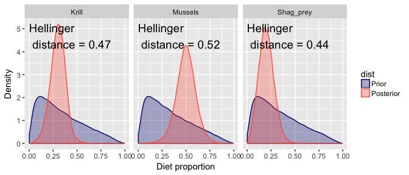

```r
xgullssmall <- plot_dists(gulls_small_in, gulls_out, prior_gulls, plotdist = T)
```

```r
xgullssmall
```

```
## Hellinger - Discrete
##           Group1
## Krill       0.47
## Mussels     0.52
## Shag_prey   0.44
##
## Hellinger - Continuous
##           Group1
## Krill       0.47
## Mussels     0.52
## Shag_prey   0.44
```

The Hellinger distance statistic provides a metric that measures the difference between two distributions. Values closer to 1 indicate the posterior is increasingly different from the prior. In this case divergence is only moderate, due the small consumer sample size and the broad sd on the sources. See `?plot_dists` for more information.

There are two ways the Hellinger distance can increase - the posterior can get narrower but retain the same mean as the prior. This would indicate we have more information about a consumer’s diet, but that the information agrees with the prior.

The Hellinger distance could also increase if the mean of the posterior shifts from the prior, indicating that the data do not agree with the prior for a source.

### Posterior shrink

An alternate method for prior sensitivity analysis is to calculate the ‘shrink’ of a posterior parameter estimate towards it’s maximum likelihood estimate and away from the prior. In contrast to the Hellinger distance, shrink is calculated on a single parameter, rather than across the distribution.

To obtain maximum likelihood from mixing models we use the data cloning method. See [Lele et al. 2007](http://onlinelibrary.wiley.com/doi/10.1111/j.1461-0248.2007.01047.x/full) for more details on this method.

The key point is to choose an adequately large cloning number, `K`, where larger values of `K` will give more accurate maximum likelihood estimates, but require more computational time.

The code below will re-run our gulls `simmr` model with a cloned data-frame (this may take awhile):

```r
K <- 80
gulls_clone <- simmr_clone(gulls_small_in, K = K, mcmc.control = mcmccontrol, prior.control = prior_gulls)
```

A `simmr` run on the cloned gulls data is also available directly in the `remixsiar` package for convenience:

```r
data(gulls_clone)
```

It is recommended that you run your model with a range of `K` values to check maximum likelihood estimates have converged to a stable value. See [Lele et al. 2007](http://onlinelibrary.wiley.com/doi/10.1111/j.1461-0248.2007.01047.x/full) for more guidance and some advice for reducing computational time.

We then calculate posterior shrink comparing our Bayesian and maximum likelihood estimates of a parameter. In this case we choose the mean contributions:

```r
rout <- remix_shrink(gulls_out, gulls_clone, prior_gulls, stat = mean)
rout
```

```
## Estimates for the mean
##  80 data replicates used to estimate MLE
##
##           shrink theta_post theta_prior theta_MLE theta_SE
## Krill          1        0.3        0.33       0.3     0.71
## Mussels        1        0.5        0.34       0.5     0.92
## Shag_prey      1        0.2        0.33       0.2     0.71
```

For all sources the shrink is 1, indicating complete convergence between the mean estimates from Bayesian and maximum likelihood methods. Though not the frequentist standard errors (last column) are broad.

## Visualising correlations among estimates of source contributions

In addition to estimating probability distributions for the marginal contribution of each source to a consumer’s diet, isotope mixing models also estimate correlations among estimates source contributions. The correlations reflect probabilities about the likely mixes of different sources.

Visualing correlations among source estimates is a standard step in evaluation of isotope mixing models. `remixsiar` provides two functions for running and principal components analysis to aid interpretation of correlations amon source estimates. PCA is run on the MCMC chains for sources. These functions are simply wrappers for R’s `prcomp`, which are designed to work with `simmr_output` objects.

To run a PCA on a `simmr_output` object:

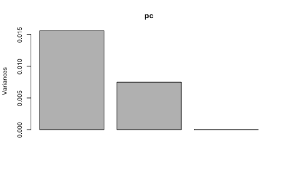

```r
pc <- remix_pca(gulls_out)
plot(pc)
```

We thus get a standard visualisation about how much variation is explained by the axes. To plot two axes (typically the first two):

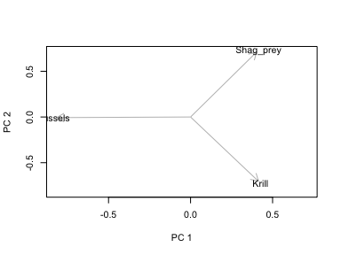

```r
remix_pcaplot(pc, axes = c(1,2))
```

## Evaluating models for bias and precision

`remixsiar` provides tools for evaluating precision and bias of predictions for consumer isotope ratios. See [Bolker 2008](http://press.princeton.edu/titles/8709.html) for a general guide to evaluation of prediction and bias.  
For mixing models, bias in predictions of consumer isotope ratios may indicate a misspecified model. For instance, a key source may be missed or trophic fractionation estimates may be too low. We can obtain by statistics by simulating data from the fitted model. For instance try:

```r
sims_gulls <- simdata(gulls_small_in, gulls_out, fast = T)
sims_gulls
```

```
## Bias and RMSE for mixture values
##
## Bias
##       Group1
## delC -0.1700
## delN  0.0148
##
##  Root mean squared error
##      Group1
## delC  0.274
## delN  0.207
```

Which prints estimates of bias, which are the average deviation of the consumer data from the model predicted mean isotope ratios. The root mean squared error is a measure of variance, and indicates the average variation about the model predicted mean.

We can visualise bias and variance on an isospace plot

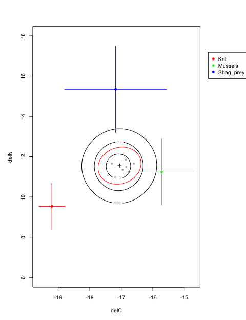

```r
remix_2DPI(sims_gulls, gulls_small_in, ylims = c(6, 18), prob = 0.05)
```

Here we see the consumer data fall well within the predictive intervals generated by the model (which are quite broad, due to the relatively large SDs on the source values).

We can also create plots of residuals on single tracers. For instance, users may be familiar with residuals checks from regression modelling. `remixsiar` can produce similar plots for isotope mixing models:

```r
xresid <- remix_PI(sims_gulls, gulls_small_in, gulls_out)
```

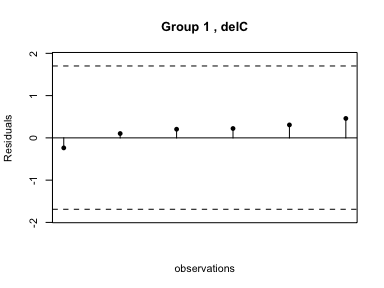

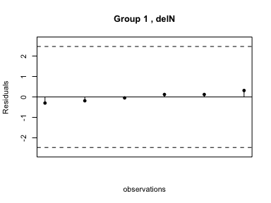

We want to see that residuals are evenly, and normally, distributed about their mean values. A large proportion of positive or negative values would indicate bias.

We can run a (Bayesian) t-test (using the package `BEST`) to obtain the probability that the mean of the residuals differs from zero:

```r
library(BEST)
apply(xresid$resid[[1]], 2, BESTmcmc)
```

```
## [[1]]
## MCMC fit results for BEST analysis:
## 100002 simulations saved.
##          mean      sd  median    HDIlo   HDIup  Rhat n.eff
## mu     0.1844  0.1493  0.1869 -0.10587  0.4681 1.004 25692
## nu    31.0764 29.9258 21.8499  1.00054 90.4528 1.002 17519
## sigma  0.3099  0.1753  0.2689  0.09065  0.6200 1.011  8781
##
## 'HDIlo' and 'HDIup' are the limits of a 95% HDI credible interval.
## 'Rhat' is the potential scale reduction factor (at convergence, Rhat=1).
## 'n.eff' is a crude measure of effective sample size.
##
## [[2]]
## MCMC fit results for BEST analysis:
## 100002 simulations saved.
##            mean      sd    median   HDIlo   HDIup  Rhat n.eff
## mu     0.004482  0.1454  0.004519 -0.2776  0.3004 1.000 35113
## nu    32.507120 29.7357 23.639892  1.0040 91.5574 1.001 18742
## sigma  0.308520  0.1603  0.268087  0.1096  0.6096 1.001 11616
##
## 'HDIlo' and 'HDIup' are the limits of a 95% HDI credible interval.
## 'Rhat' is the potential scale reduction factor (at convergence, Rhat=1).
## 'n.eff' is a crude measure of effective sample size.
```

In this case the 95% credibility intervals on the means for both tracers overlap with zero - compare `HDIlo` and `HDIup` columns for hte parameter `mu` Thus, model bias is not an issue for the gulls data.

## Further reading

`remixsiar` package: Brown et al. submitted

Isotope mixing models:

The `simmr` package, in R type: `vignette('simmr')`

For information about prior sensitivity analysis see (pay-walled):  
[Berger JO (1985) Statistical Decision Theory and Bayesian Analysis, Second Edition, Springer, New York.](http://www.springer.com/in/book/9780387960982)

For information about model cloning (pay-walled):  
[Lele SR, Dennis B, Lutscher F. Data cloning: easy maximum likelihood estimation for complex ecological models using Bayesian Markov chain Monte Carlo methods. Ecology letters. 2007 Jul 1;10(7):551-63.](http://onlinelibrary.wiley.com/doi/10.1111/j.1461-0248.2007.01047.x/full)  
Click [here](http://bacbuc.hd.free.fr/WebDAV/data/DOM/StatMeths/Lele-EL2007.pdf) for an open access versio?n.

General information about model evaluation (pay-walled):  
[Bolker BM. Ecological models and data in R. Princeton University Press; 2008 Jul 21.](http://press.princeton.edu/titles/8709.html)

Best practices for isotope mixing models (pay-walled): [Phillips DL, Inger R, Bearhop S, Jackson AL, Moore JW, Parnell AC, Semmens BX, Ward EJ. Best practices for use of stable isotope mixing models in food-web studies. Canadian Journal of Zoology. 2014 Aug 27;92(10):823-35.](http://www.nrcresearchpress.com/doi/abs/10.1139/cjz-2014-0127)

Technical details about isotope mixing models (pay-walled):  
[Parnell AC, Phillips DL, Bearhop S, Semmens BX, Ward EJ, Moore JW, Jackson AL, Grey J, Kelly DJ, Inger R. Bayesian stable isotope mixing models. Environmetrics. 2013 Sep 1;24(6):387-99.](http://onlinelibrary.wiley.com/doi/10.1002/env.2221/full)

To read about the real gulls data-set, which the `remixsiar` gulls data-set is based on (open access): [Masello JF, Wikelski M, Voigt CC, Quillfeldt P. Distribution patterns predict individual specialization in the diet of Dolphin Gulls. PLoS One. 2013 Jul 2;8(7):e67714.](http://journals.plos.org/plosone/article?id=10.1371/journal.pone.0067714#s5)